# Forecast daily bike rental demand using time series models

Franckie Wibisono

2025-11-18

# About Data Analysis Report

This RMarkdown file contains the report of the data analysis done for the project on forecasting daily bike rental demand using time series models in R. It contains analysis such as data exploration, summary statistics and building the time series models. The final report was completed on Tue Nov 18 12:20:02 2025.

**Data Description:**

This dataset contains the daily count of rental bike transactions between years 2011 and 2012 in Capital bikeshare system with the corresponding weather and seasonal information.

**Data Source:** https://archive.ics.uci.edu/ml/datasets/bike+sharing+dataset

**Relevant Paper:**

Fanaee-T, Hadi, and Gama, Joao. Event labeling combining ensemble detectors and background knowledge, Progress in Artificial Intelligence (2013): pp. 1-15, Springer Berlin Heidelberg

# Task One: Load and explore the data

## Load data and install packages

```r
## Import required packages
# Install timetk (required for the dataset)
# install.packages(c("timetk", "dplyr"))


# Load the package
library(timetk)
library(dplyr)
# Load the built-in dataset
data("bike_sharing_daily")

# Create a working copy
bike_data <- bike_sharing_daily
```

## Describe and explore the data

```r
# Correlation between temp/atemp and total rentals (cnt)
cor(bike_data$temp, bike_data$cnt)
```

```
## [1] 0.627494
```

```r
cor(bike_data$atemp, bike_data$cnt)
```

```
## [1] 0.6310657
```

```r
# Mean & median temp by season
bike_data %>%
  mutate(season_label = case_when(
    season == 1 ~ "Winter",
    season == 2 ~ "Spring",
    season == 3 ~ "Summer",
    season == 4 ~ "Fall"
  )) %>%
  group_by(season_label) %>%
  summarise(
    mean_temp = mean(temp),
    median_temp = median(temp),
    mean_rentals = mean(cnt)
  )
```

```
## # A tibble: 4 × 4
##   season_label mean_temp median_temp mean_rentals
##   <chr>            <dbl>       <dbl>        <dbl>
## 1 Fall             0.423       0.409        4728.
## 2 Spring           0.544       0.562        4992.
## 3 Summer           0.706       0.715        5644.
## 4 Winter           0.298       0.286        2604.
```

# Task Two: Create interactive time series plots

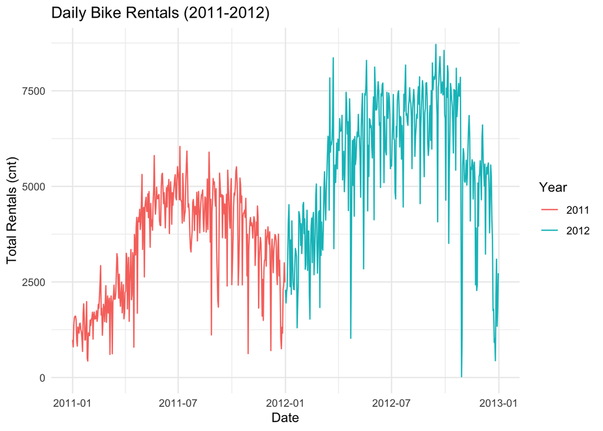

```r
library(dplyr)
library(ggplot2)
library(lubridate)
bike_data %>%
  mutate(year = year(dteday)) %>%
  ggplot(aes(x = dteday, y = cnt, color = factor(year))) +
  geom_line() +
  labs(
    title = "Daily Bike Rentals (2011-2012)",
    x = "Date",
    y = "Total Rentals (cnt)",
    color = "Year"
  ) +
  theme_minimal()
```

# Task Three: Smooth time series data

```r
# Load required packages
library(forecast)
```

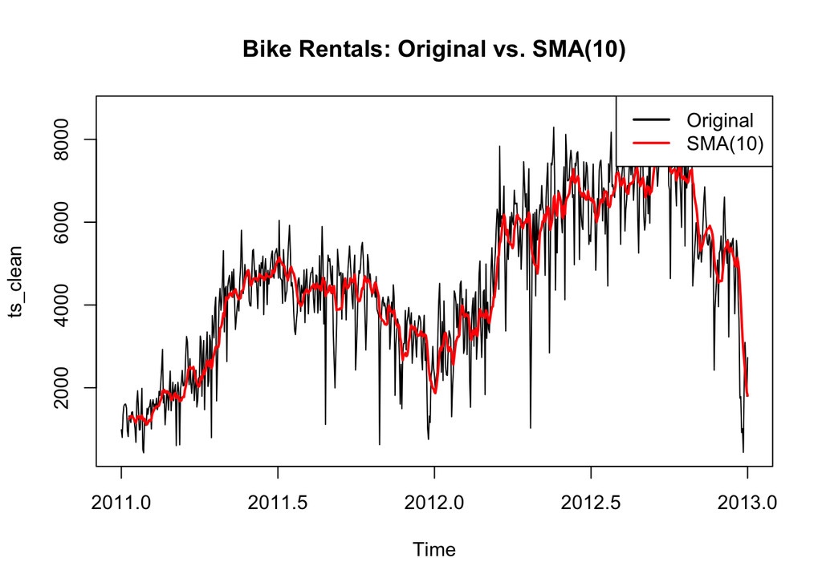

```r
library(TTR)

# Step 1: Create time series object
ts_cnt <- ts(bike_data$cnt, start = c(2011, 1), frequency = 365)

# Step 2: Clean the series
ts_clean <- tsclean(ts_cnt)

# Step 3: Compute SMA(10)
ts_sma_raw <- SMA(as.numeric(ts_clean), n = 10)

# Step 4: Align SMA with original time series (remove leading NAs for plotting)
# Create a new time series with same time index
ts_sma <- ts(ts_sma_raw, start = start(ts_clean), frequency = frequency(ts_clean))

# Step 5: Plot
plot(ts_clean, main = "Bike Rentals: Original vs. SMA(10)", col = "black", lwd = 1)
lines(ts_sma, col = "red", lwd = 2)
legend("topright", legend = c("Original", "SMA(10)"), col = c("black", "red"), lwd = 2)
```

# Task Four: Decompose and assess the stationarity of time series data

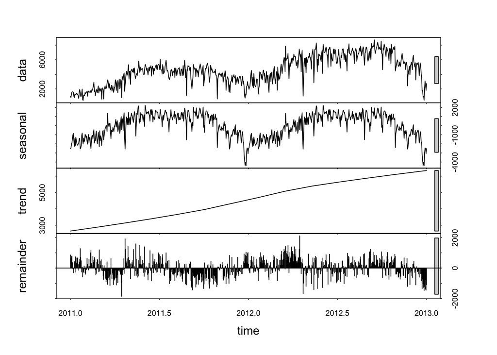

```r
# Load required packages
library(forecast)
library(tseries)  # Needed for adf.test()

# Step 1: Decompose the time series using STL
decomp <- stl(ts_clean, s.window = "periodic")
plot(decomp)
```

```r
# Step 2: Check stationarity using ADF test
adf_result1 <- adf.test(ts_clean)
print(adf_result1)
```

```
##
##  Augmented Dickey-Fuller Test
##
## data:  ts_clean
## Dickey-Fuller = -1.4435, Lag order = 9, p-value = 0.8138
## alternative hypothesis: stationary
```

```r
# Step 3: Difference the series once (to remove trend)
ts_diff <- diff(ts_clean, differences = 1)

# Step 4: Re-check stationarity on differenced series
adf_result2 <- adf.test(ts_diff)
print(adf_result2)
```

```
##
##  Augmented Dickey-Fuller Test
##
## data:  ts_diff
## Dickey-Fuller = -13.298, Lag order = 8, p-value = 0.01
## alternative hypothesis: stationary
```

# Task Five: Fit and forecast time series data using ARIMA models

```r
# Load required packages
library(forecast)
library(tseries)

# Check the structure of ts_diff
print("Length of ts_diff:")
```

```
## [1] "Length of ts_diff:"
```

```r
print(length(ts_diff))
```

```
## [1] 730
```

```r
print("Number of NA values in ts_diff:")
```

```
## [1] "Number of NA values in ts_diff:"
```

```r
print(sum(is.na(ts_diff)))
```

```
## [1] 0
```

```r
print("First 10 values of ts_diff:")
```

```
## [1] "First 10 values of ts_diff:"
```

```r
print(head(ts_diff, 10))
```

```
## Time Series:
## Start = c(2011, 2)
## End = c(2011, 11)
## Frequency = 365
##  [1] -184  548  213   38    6  -96 -551 -137  499  -58
```

```r
print("Is ts_diff a time series object?")
```

```
## [1] "Is ts_diff a time series object?"
```

```r
print(is.ts(ts_diff))
```

```
## [1] TRUE
```

```r
# Remove any remaining NA values (if any)
ts_diff_clean <- na.omit(ts_diff)

print("Length after removing NAs:")
```

```
## [1] "Length after removing NAs:"
```

```r
print(length(ts_diff_clean))
```

```
## [1] 730
```

```
## [1] "Model fitted successfully!"
## Series: ts_diff_clean
## ARIMA(1,0,1) with zero mean
##
## Coefficients:
##          ar1      ma1
##       0.3692  -0.8751
## s.e.  0.0437   0.0213
##
## sigma^2 = 663543:  log likelihood = -5928.18
## AIC=11862.37   AICc=11862.4   BIC=11876.15
##
## Training set error measures:
##                    ME     RMSE      MAE      MPE     MAPE      MASE      ACF1
## Training set 11.14636 813.4647 588.9245 157.0058 233.5991 0.6555386 0.0110962
```

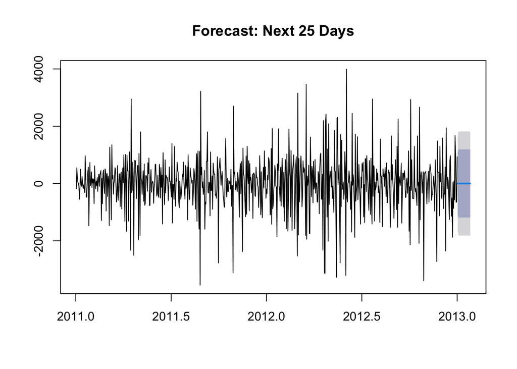

```r
# Try fitting ARIMA on the cleaned version
if (length(ts_diff_clean) > 10) {
  fit_auto <- auto.arima(ts_diff_clean, seasonal = FALSE, stepwise = TRUE, approximation = TRUE)
  print("Model fitted successfully!")
  print(summary(fit_auto))

  # Forecast
  fc <- forecast(fit_auto, h = 25)
  plot(fc, main = "Forecast: Next 25 Days")
} else {
  stop("Not enough data to fit ARIMA model.")
}
```

# Task Six: Findings and Conclusions

## Findings and Conclusions

Throughout this project, I analyzed daily bike rental demand in Washington, DC (2011-2012) using time series modeling techniques. Here are my key findings:

### 1. Data Exploration

- There is a **strong positive correlation** between temperature and total rentals (`cor(temp, cnt) = 0.627`).
- Rentals peak in **Summer** (mean = 5,644/day) and dip in **Winter** (mean = 2,604/day), confirming that weather heavily influences demand.

### 3. Stationarity & Decomposition

- The original series was **non-stationary** (p-value > 0.05 in ADF test).
- After **first-order differencing**, the series became **stationary** (p-value = 0.01), making it suitable for ARIMA modeling.

### 4. ARIMA Forecasting

- An `ARIMA(1,0,1)` model was fitted to the differenced series.
- The forecast for the next 25 days shows **stable changes around zero**, suggesting no strong upward or downward trend in daily *changes* of rentals.

### Final Thoughts

This project reinforced how real-world data (like bike rentals) can be modeled using time series methods. While the forecast is for *changes*, not absolute values, the process — from exploration to modeling — mirrors real business analytics workflows. For future work, I would explore adding external variables (e.g., holidays, events) to improve accuracy.